# Exercise Solutions: Joining and Reshaping

University of North Carolina at Chapel Hill

## Setup

**Download Data**  
Download data

- Extract the data within the data directory. You should end up with a folder called “brazilian-ecommerce”.

```r
# Load the tidyverse package.
library(tidyverse)
```

1. Read olist_public_dataset_v2.csv into R. Explore the dataset. If necessary, refer to the metadata provided [here](https://www.kaggle.com/olistbr/brazilian-ecommerce).

**Answer:**

```r
data <- read_csv("data/brazilian-ecommerce/olist_public_dataset_v2.csv")
summary(data)
```

```
##    order_id         order_status       order_products_value order_freight_value
##  Length:100000      Length:100000      Min.   :    2.00     Min.   :   0.00
##  Class :character   Class :character   1st Qu.:   46.99     1st Qu.:  13.47
##  Mode  :character   Mode  :character   Median :   83.65     Median :  16.79
##                                        Mean   :  129.19     Mean   :  21.74
##                                        3rd Qu.:  145.90     3rd Qu.:  23.01
##                                        Max.   :13440.00     Max.   :1562.10
##
##  order_items_qty order_sellers_qty order_purchase_timestamp
##  Min.   : 1.0    Min.   : 1.000    Min.   :2016-09-04 21:15:19
##  1st Qu.: 1.0    1st Qu.: 1.000    1st Qu.:2017-07-22 17:56:17
##  Median : 1.0    Median : 1.000    Median :2017-11-24 17:15:32
##  Mean   : 1.1    Mean   : 1.142    Mean   :2017-11-20 21:08:19
##  3rd Qu.: 1.0    3rd Qu.: 1.000    3rd Qu.:2018-03-19 16:46:11
##  Max.   :20.0    Max.   :30.000    Max.   :2018-09-28 10:54:31
##
##  order_aproved_at              order_estimated_delivery_date
##  Min.   :2016-09-15 12:16:38   Min.   :2016-10-04 00:00:00
##  1st Qu.:2017-07-23 05:44:40   1st Qu.:2017-08-15 00:00:00
##  Median :2017-11-25 00:34:47   Median :2017-12-18 00:00:00
##  Mean   :2017-11-21 08:33:28   Mean   :2017-12-15 05:27:31
##  3rd Qu.:2018-03-20 03:30:46   3rd Qu.:2018-04-12 00:00:00
##  Max.   :2018-09-28 11:05:22   Max.   :2018-12-13 00:00:00
##  NA's   :18
##  order_delivered_customer_date customer_id        customer_city
##  Min.   :2016-10-11 13:46:32   Length:100000      Length:100000
##  1st Qu.:2017-08-03 20:35:39   Class :character   Class :character
##  Median :2017-12-07 22:29:32   Mode  :character   Mode  :character
##  Mean   :2017-12-04 19:09:17
##  3rd Qu.:2018-04-06 19:03:03
##  Max.   :2018-10-03 03:46:34
##  NA's   :2405
##  customer_state     customer_zip_code_prefix product_category_name
##  Length:100000      Length:100000            Length:100000
##  Class :character   Class :character         Class :character
##  Mode  :character   Mode  :character         Mode  :character
##
##
##
##
```

[output cut: 17 more lines]

```
##  Length:100000          Min.   :2016-10-06 00:00:00
##  Class :character       1st Qu.:2017-08-03 00:00:00
##  Mode  :character       Median :2017-12-08 00:00:00
##                         Mean   :2017-12-03 19:24:55
##                         3rd Qu.:2018-04-05 00:00:00
##                         Max.   :2018-10-03 00:00:00
##
##  review_answer_timestamp
##  Min.   :2016-10-07 21:32:28
##  1st Qu.:2017-08-06 21:47:03
##  Median :2017-12-11 14:19:35
##  Mean   :2017-12-07 03:15:03
##  3rd Qu.:2018-04-07 02:21:19
##  Max.   :2018-10-03 12:54:08
##
```

2. Read product_category_name_translation.csv into R. Merge this dataframe into olist_public_dataset_v2.csv using `product_category_name` as the key variable.

**Answer:**

```r
trans <- read_csv("data/brazilian-ecommerce/product_category_name_translation.csv")
data_tr <- left_join(data, trans, by=c("product_category_name"="product_category_name"))
```

Let’s explore which products are most frequently purchased together:

3. Use `group_by` and `summarize` to find the total `order_items_qty` for each `product_category_name_english` in each `customer state`. [Review](https://unc-libraries-data.github.io/R-Open-Labs/week3_Transformations/R_OpenLabs_3_Transformations.html)

**Answer:**

```r
products_long <- data_tr %>% group_by(product_category_name_english, customer_state) %>%
  summarize(total_orders = sum(order_items_qty))
```

4. Use `pivot_wider` to create a new dataframe with a row for each `customer_state` and a column for each `product_category_name_english`. Name this dataframe `products`.

**Answer:**

```r
products <- pivot_wider(products_long, id=customer_state, names_from=product_category_name_english, values_from=total_orders)
```

5. Run the two lines of code below (make sure your dataframe from step 4 is called `products`!)

```
products <- ungroup(products) #remove grouping
products[is.na(products)] <- 0 #replace missing data with zeroes
```

**Answer:**

```r
products <- ungroup(products) #remove grouping
products[is.na(products)] <- 0 #replace missing data with zeroes
```

6. Use `ggpairs` or other Exploratory Data Analysis techniques to look for relationships between purchases of `small_appliances`,`consoles_games`,`air_conditioning`, and `construction_tools_safety`. (Remember to run `library(GGally)` before using `ggpairs`).

**Answer:**

```r
library(GGally)
```

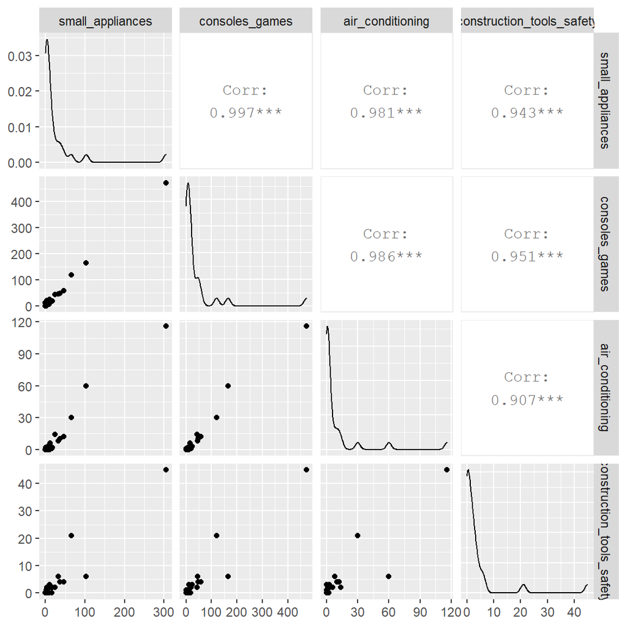

```r
products %>% select(small_appliances, consoles_games, air_conditioning, construction_tools_safety) %>%
  ggpairs()
```

Unsurpsisingly, there is a positive relationship between each pair of variables. This probably represents the underlying influence of popluation - states with larger populations probably order more of everything!

7. Repeat problems 3-6 with `order_products_value` (i.e. the amount spent vs the quantity purchased). Do you see different patterns? Explore other product categories.

**Answer:**

```r
prod_value <- data_tr %>% group_by(product_category_name_english, customer_state) %>%
  summarize(total_value = sum(order_products_value)) %>%
  pivot_wider(id=customer_state, names_from=product_category_name_english, values_from=total_value) %>%
  ungroup()
```

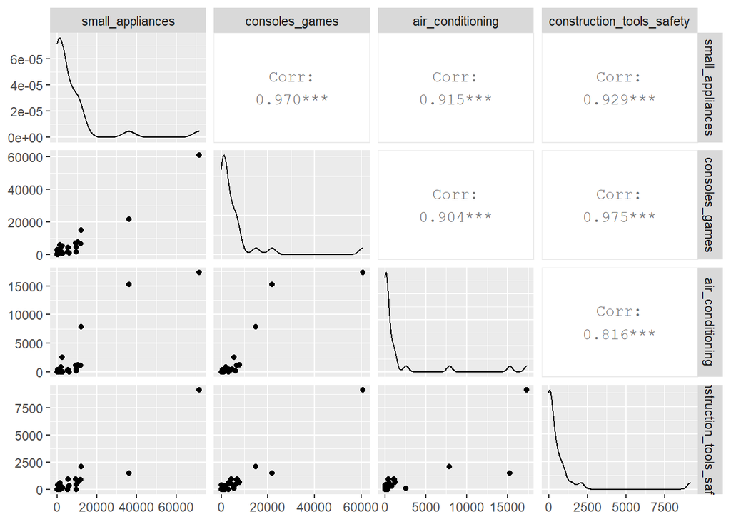

```r
prod_value[is.na(prod_value)] <- 0

prod_value %>% select(small_appliances, consoles_games, air_conditioning, construction_tools_safety) %>%
  ggpairs()
```

We see similar, if a bit weaker, relationships.

8. Use `pivot_longer` and then `pivot_wider` to convert your `products` dataframe to one where each row is a different `product_category_name_english` and each column represents a different `customer_state`.

**Answer:**

```r
prod_by_state <- products %>% pivot_longer(cols=-customer_state) %>%
  pivot_wider(names_from = customer_state, values_from =value)
```

9. Choose 5 states. Which of these states have the most similar patterns of spending (as measured by correlation)?

**Answer:**

```
## Note: Using an external vector in selections is ambiguous.
## i Use `all_of(chosen_states)` instead of `chosen_states` to silence this message.
## i See <https://tidyselect.r-lib.org/reference/faq-external-vector.html>.
```

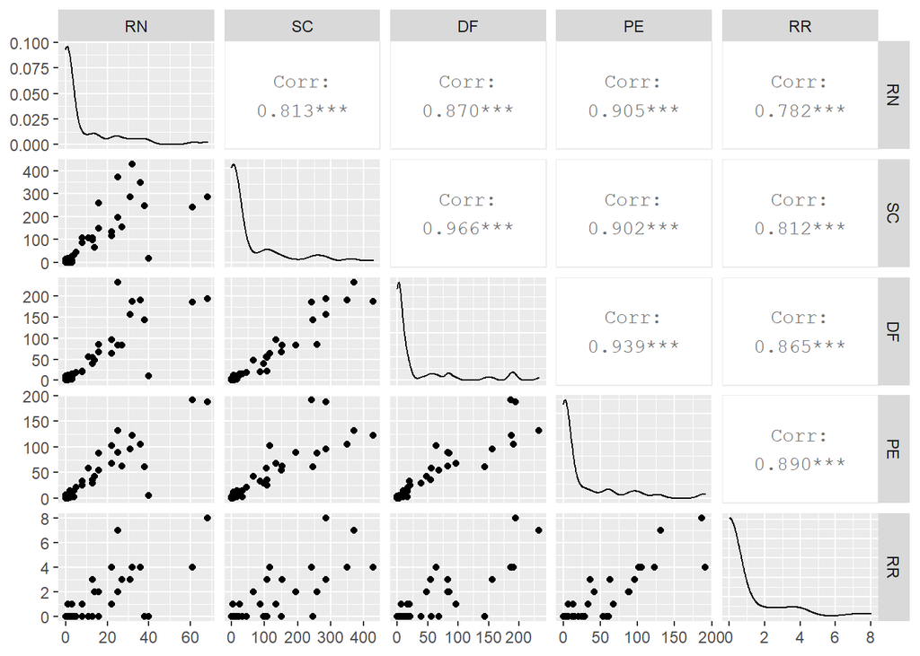

```r
chosen_states <- c("RN", "SC", "DF", "PE", "RR")
prod_by_state %>% select(chosen_states) %>% ggpairs()
```